# Matching

## The Effect of Catholic School on Student Achievement

Example inspired by Simon Ejdemyr: https://sejdemyr.github.io/r-tutorials/statistics/tutorial8.html

#### Reference links:

1. `MatchIt`: https://cran.r-project.org/web/packages/MatchIt/vignettes/matchit.pdf
2. `Cobalt` (optional library for matching plots and extra features): https://cran.r-project.org/web/packages/cobalt/vignettes/cobalt_A0_basic_use.html
3. `kableExtra` (for formatting data frames): https://cran.r-project.org/web/packages/kableExtra/vignettes/awesome_table_in_html.html
4. `Stargazer` (for formatting model outputs): https://www.jakeruss.com/cheatsheets/stargazer/
5. Video overview of matching concepts: https://fr.coursera.org/lecture/crash-course-in-causality/overview-of-matching-JQfPC

```r
library(dplyr) # for data wrangling
library(readr) # for loading the .csv data
library(ggplot2) # for creating plots
library(stargazer) # for formatting model output
library(kableExtra) # for formatting data frames
library(MatchIt) # for matching

set.seed(123) # for consistent results
```

## Data Prep and EDA

First, let’s read in the data. We will remove a few variables that won’t be useful for our analysis. Then, we will compare the students *pre-matching* on their standardized math scores (`c5r2mtsc_std`).

### Exploration of the data

```r
ecls <- readr::read_csv("https://raw.githubusercontent.com/seramirezruiz/stats-ii-lab/master/Session%204/data/ecls.csv")

ecls <- ecls %>%
  dplyr::select(-childid, -race, -w3daded,
                -w3momed, -w3inccat) # drop these columns (-)

ecls %>%
  dplyr::group_by(catholic) %>%
  dplyr::summarize(n_students = n(),
                   mean_math = mean(c5r2mtsc_std),
                   std_error = sd(c5r2mtsc_std) / sqrt(n_students)) %>%
  round(3) %>% # round the results
  kable() %>% # create kable table
  kable_styling() # view kable table
```

| catholic | n_students | mean_math | std_error |
| --- | --- | --- | --- |
| 0 | 9568 | -0.031 | 0.010 |
| 1 | 1510 | 0.194 | 0.022 |

We can see that we have many more students that did not attend Catholic school than those who did, and the Catholic school students have a mean math score that is higher.

### NATE

First, let’s calculate the NATE of Catholic school on student achievement (without adjusting for any covariates) to compare the means of the two groups.

```r
summary(lm(c5r2mtsc_std ~ catholic, data = ecls))
```

```
##
## Call:
## lm(formula = c5r2mtsc_std ~ catholic, data = ecls)
##
## Residuals:
##     Min      1Q  Median      3Q     Max
## -3.5299 -0.6634  0.0609  0.6770  3.4643
##
## Coefficients:
##             Estimate Std. Error t value Pr(>|t|)
## (Intercept) -0.03060    0.01019  -3.002  0.00269 **
## catholic     0.22446    0.02761   8.130 4.75e-16 ***
## ---
## Signif. codes:  0 '***' 0.001 '**' 0.01 '*' 0.05 '.' 0.1 ' ' 1
##
## Residual standard error: 0.9971 on 11076 degrees of freedom
## Multiple R-squared:  0.005932,   Adjusted R-squared:  0.005842
## F-statistic:  66.1 on 1 and 11076 DF,  p-value: 4.752e-16
```

### Balance Table

Now, let’s create a balance table to identify the relevant co-variates in the unmatched dataset.

```r
ecls %>%
  dplyr::group_by(catholic) %>%
  dplyr::summarize_all(funs(mean(., na.rm = T))) %>% # summarize the mean of every variable
  t() %>% # transpose data
  as.data.frame() %>% # after transposing, convert from matrix to df
  add_rownames("variable") %>% # rownames to explicit column
  dplyr::rename(no_catholic = V1, catholic = V2) %>% # rename columns that are created by as.data.frame
  dplyr::mutate(difference = catholic - no_catholic,
         differencePerc = difference / (catholic + no_catholic)) %>% # create new columns for difference between groups
  dplyr::mutate_if(is.numeric, round, 3) %>% # round numeric columns
  arrange(desc(differencePerc)) %>%
  knitr::kable() %>% # create kable table
  kableExtra::kable_styling() # view kable table
```

| variable | no_catholic | catholic | difference | differencePerc |
| --- | --- | --- | --- | --- |
| c5r2mtsc_std | -0.031 | 0.194 | 0.224 | 1.375 |
| catholic | 0.000 | 1.000 | 1.000 | 1.000 |
| w3income | 54889.159 | 82074.301 | 27185.141 | 0.198 |
| race_white | 0.556 | 0.725 | 0.169 | 0.132 |
| w3momscr | 43.114 | 47.492 | 4.379 | 0.048 |
| w3dadscr | 42.713 | 46.356 | 3.643 | 0.041 |
| p5hmage | 37.561 | 39.575 | 2.014 | 0.026 |
| c5r2mtsc | 50.209 | 52.389 | 2.180 | 0.021 |
| p5hdage | 40.392 | 41.988 | 1.596 | 0.019 |
| p5numpla | 1.133 | 1.093 | -0.040 | -0.018 |
| race_asian | 0.066 | 0.052 | -0.014 | -0.118 |
| race_hispanic | 0.181 | 0.131 | -0.050 | -0.161 |
| w3daded_hsb | 0.488 | 0.259 | -0.229 | -0.306 |
| w3momed_hsb | 0.464 | 0.227 | -0.237 | -0.343 |
| race_black | 0.136 | 0.054 | -0.083 | -0.436 |
| w3povrty | 0.219 | 0.038 | -0.181 | -0.705 |
| p5fstamp | 0.129 | 0.015 | -0.114 | -0.788 |

We can see that the largest magnitude differences are for:

- variables on race
- `w3momed_hsb`: dummy variable with 1 = mother’s education level is high school or below, 0 = some college or above
- `w3income`: family income
- `w3povrty`: poverty score dummy
- `p5fstamp`: food stamp dummy

## Matching with `MatchIt`

`MatchIt` is designed for causal inference with a dichotomous treatment variable and a set of pretreatment control variables. Any number or type of dependent variables can be used.

The basic syntax is as follows: `matched <- matchit(treat ~ x1 + x2, data = mydata)`, where `treat` is the dichotomous treatment variable, and `x1` and `x2` are pre-treatment co-variates, all of which are contained in the data frame `mydata`. As you can see, the outcome variable is not included in the matching procedure.

`MatchIt` is capable of using several matching *methods*:

- Exact (*method = “exact”*): The simplest version of matching is exact. This technique matches each treated unit to all possible control units with exactly the same values on all the covariates, forming subclasses such that within each subclass all units (treatment and control) have the same covariate values.
- Subclassification (*method = “subclass”*): When there are many covariates (or some covariates can take a large number of values), finding sufficient exact matches will often be impossible. The goal of subclassification is to form subclasses, such that in each of them the distribution (rather than the exact values) of covariates for the treated and control groups are as similar as possible.
- Nearest Neighbor (*method = “nearest”*): Nearest neighbor matching selects the best control matches for each individual in the treatment group. Matching is done using a distance measure (propensity score) specified by the distance option (default = *logit*).
- As well as optimal matching, full matching, genetic matching, and coarsened exact matching, all of which are detailed in the documentation.

A few additional arguments are important to know about:

- *distance*: this refers to propensity scores. There are many options for how to calculate these within `MatchIt`.
- *discard*: specifies whether to discard units that fall outside some measure of support of the distance measure (default is “none”, discard no units). For example, if some treated units have extremely high propensity scores that are higher than any control units, we could drop those.
- *replace*: a logical value indicating whether each control unit can be matched to more than one treated unit (default is `replace = FALSE`, each control unit is used at most once).
- *ratio*: the number of control units to match to each treated unit (default is `ratio = 1`).
- There are also some optional arguments for most of the matching methods, which you can read about in the documentation if you are interested.

### Exact Matching

We can use a combination of the results from our balance table and theory to identify which variables to use for matching. Let’s perform an exact match with:

- `race_white`: Is the student white (1) or not (0)?
- `p5hmage`: Mother’s age
- `w3income`: Family income
- `p5numpla`: Number of places the student has lived for at least 4 months
- `w3momed_hsb`: Is the mother’s education level high-school or below (1) or some college or more (0)?

```r
# first we must omit missing values (MatchIt does not allow missings)
match_data <- ecls %>%
  dplyr::select(catholic, c5r2mtsc_std, race_white, p5hmage,
         w3income, p5numpla, w3momed_hsb) %>%
  na.omit()

str(match_data) #Let's see how many observations do we have
```

```
## tibble [9,267 × 7] (S3: tbl_df/tbl/data.frame)
##  $ catholic    : num [1:9267] 0 0 0 1 0 0 0 0 0 0 ...
##  $ c5r2mtsc_std: num [1:9267] 0.982 0.594 0.491 1.451 2.596 ...
##  $ race_white  : num [1:9267] 1 1 1 1 1 1 1 0 1 1 ...
##  $ p5hmage     : num [1:9267] 47 41 43 38 47 30 41 38 28 31 ...
##  $ w3income    : num [1:9267] 62501 45001 62501 87501 150001 ...
##  $ p5numpla    : num [1:9267] 1 1 1 1 1 1 1 1 1 1 ...
##  $ w3momed_hsb : num [1:9267] 0 0 0 0 0 0 0 1 1 1 ...
##  - attr(*, "na.action")= 'omit' Named int [1:1811] 3 20 22 27 33 36 45 48 52 55 ...
##   ..- attr(*, "names")= chr [1:1811] "3" "20" "22" "27" ...
```

```r
# perform exact match
exact_match <- MatchIt::matchit(catholic ~ race_white + p5hmage + w3income +
                                  p5numpla + w3momed_hsb,
                                method = "exact",
                                data = match_data)

# Try seeing the output in the console with summary(exact_match)

# grab the matched data
data_exact_match <- MatchIt::match.data(exact_match)

str(data_exact_match)
```

```
## matchdat [5,405 × 9] (S3: matchdata/tbl_df/tbl/data.frame)
##  $ catholic    : num [1:5405] 0 0 0 1 0 0 0 0 0 0 ...
##  $ c5r2mtsc_std: num [1:5405] 0.982 0.594 0.491 1.451 2.596 ...
##  $ race_white  : num [1:5405] 1 1 1 1 1 1 1 1 1 1 ...
##  $ p5hmage     : num [1:5405] 47 41 43 38 47 41 38 38 27 40 ...
##  $ w3income    : num [1:5405] 62501 45001 62501 87501 150001 ...
##  $ p5numpla    : num [1:5405] 1 1 1 1 1 1 1 1 1 1 ...
##  $ w3momed_hsb : num [1:5405] 0 0 0 0 0 0 0 0 1 1 ...
##  $ weights     : Named num [1:5405] 0.147 1.744 1.031 1 0.191 ...
##   ..- attr(*, "names")= chr [1:5405] "1" "2" "3" "4" ...
##  $ subclass    : Factor w/ 460 levels "1","2","3","4",..: 1 2 3 123 4 5 6 7 8 9 ...
##   ..- attr(*, "names")= chr [1:5405] "1" "2" "3" "4" ...
##  - attr(*, "na.action")= 'omit' Named int [1:1811] 3 20 22 27 33 36 45 48 52 55 ...
##   ..- attr(*, "names")= chr [1:1811] "3" "20" "22" "27" ...
##  - attr(*, "weights")= chr "weights"
##  - attr(*, "subclass")= chr "subclass"
```

```r
# estimate effect again
summary(lm(c5r2mtsc_std ~ catholic,
           data = data_exact_match))
```

```
##
## Call:
## lm(formula = c5r2mtsc_std ~ catholic, data = data_exact_match)
##
## Residuals:
##     Min      1Q  Median      3Q     Max
## -3.5618 -0.5838  0.0506  0.6410  3.1143
##
## Coefficients:
##             Estimate Std. Error t value Pr(>|t|)
## (Intercept)  0.31932    0.01453  21.981  < 2e-16 ***
## catholic    -0.10072    0.02991  -3.368 0.000764 ***
## ---
## Signif. codes:  0 '***' 0.001 '**' 0.01 '*' 0.05 '.' 0.1 ' ' 1
##
## Residual standard error: 0.9336 on 5403 degrees of freedom
## Multiple R-squared:  0.002094,   Adjusted R-squared:  0.00191
## F-statistic: 11.34 on 1 and 5403 DF,  p-value: 0.0007638
```

Now we can see that the mean in the group that did not attend Catholic school is actually about 0.10 higher than the mean for those who did. The results are statistically significant given that the confidence interval does not contain zero, and we have a fairly small p-value.

### Propensity Scores

If we want to perform non-exact matching, we can use propensity scores. We can generate these manually using a probit model on the unmatched data set.

```r
# create a new column with income by the thousands for more interpretable output
ecls <- ecls %>%
  dplyr::mutate(w3income_1k = w3income / 1000)

# estimate logit model
m_ps <- glm(catholic ~ race_white + w3income_1k +
              p5hmage + p5numpla + w3momed_hsb,
            family = binomial(link = "probit"), # you can also use a logit link here
            data = ecls)

# extract predicted probabilities
# type = "response" option tells R to output probabilities of the form P(Y = 1|X)
prs_df <- dplyr::tibble(pr_score = predict(m_ps, type = "response"),
                        catholic = m_ps$model$catholic) # the actual values
```

Let’s plot the propensity scores by treatment group to explore common support:

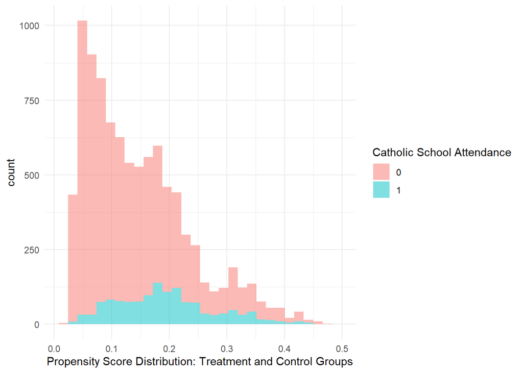

```r
ggplot(prs_df, aes(x = pr_score, fill = factor(catholic))) +
  geom_histogram(alpha = 0.5) +
  theme_minimal() +
  labs(x = "Propensity Score Distribution: Treatment and Control Groups",
       fill = "Catholic School Attendance")
```

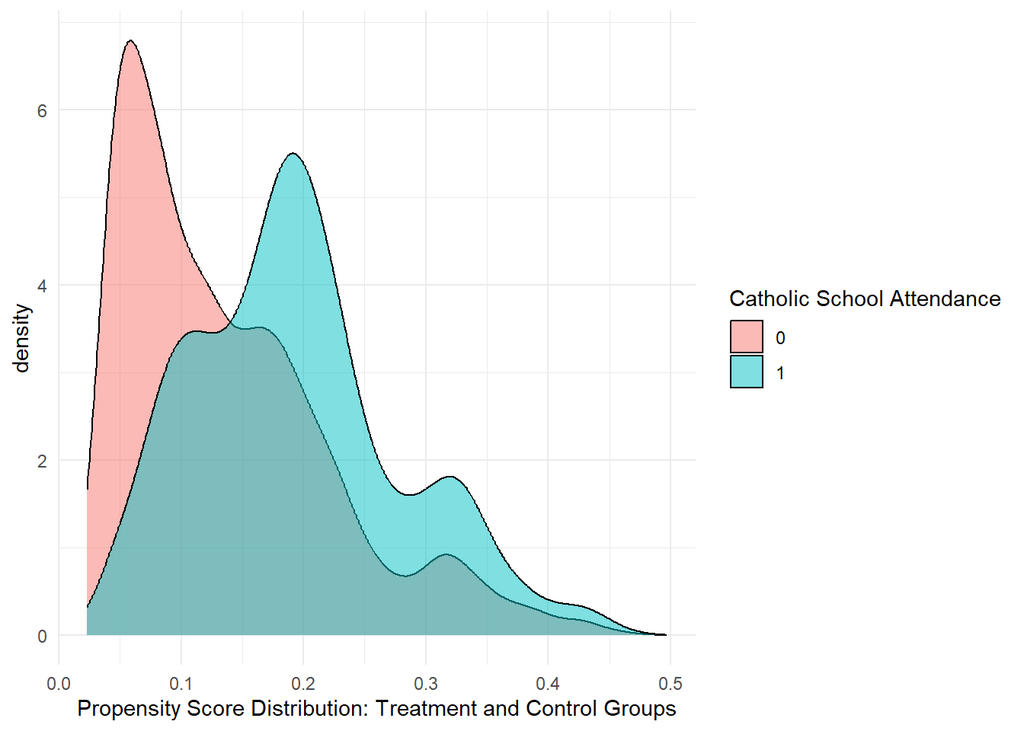

```r
ggplot(prs_df, aes(x = pr_score, fill = factor(catholic))) +
  geom_density(alpha = 0.5) +
  theme_minimal() +
  labs(x = "Propensity Score Distribution: Treatment and Control Groups",
       fill = "Catholic School Attendance")
```

### Non-Exact Matching

`MatchIt` can generate propensity scores itself, so we don’t need to manually go through the process above. Let’s try putting together a non-exact matching formula yourself! Try:

- nearest neighbor matching
- with replacement
- with a one-to-one ratio
- on the *match_data* dataset

```r
one_match <- MatchIt::matchit(catholic ~ race_white + w3income + p5hmage +
                                p5numpla + w3momed_hsb,
                              method = "nearest",
                              ratio = 1,
                              replace = TRUE,
                              data = match_data)

summary(one_match)
```

```
##
## Call:
## MatchIt::matchit(formula = catholic ~ race_white + w3income +
##     p5hmage + p5numpla + w3momed_hsb, data = match_data, method = "nearest",
##     replace = TRUE, ratio = 1)
##
## Summary of Balance for All Data:
##             Means Treated Means Control Std. Mean Diff. Var. Ratio eCDF Mean
## distance           0.1927        0.1379          0.6486     1.0007    0.2086
## race_white         0.7411        0.5914          0.3418          .    0.1497
## w3income       82568.9357    55485.0210          0.5777     1.1373    0.1565
## p5hmage           39.5932       37.5658          0.3874     0.6383    0.0408
## p5numpla           1.0917        1.1298         -0.1242     0.6132    0.0076
## w3momed_hsb        0.2234        0.4609         -0.5703          .    0.2375
##             eCDF Max
## distance      0.3109
## race_white    0.1497
## w3income      0.3062
## p5hmage       0.1893
## p5numpla      0.0277
## w3momed_hsb   0.2375
##
## Summary of Balance for Matched Data:
##             Means Treated Means Control Std. Mean Diff. Var. Ratio eCDF Mean
## distance           0.1927        0.1927          0.0000     0.9995    0.0000
## race_white         0.7411        0.7493         -0.0186          .    0.0081
## w3income       82568.9357    81775.6653          0.0169     1.0094    0.0036
## p5hmage           39.5932       39.6169         -0.0045     1.0221    0.0015
## p5numpla           1.0917        1.0777          0.0459     1.1628    0.0031
## w3momed_hsb        0.2234        0.2226          0.0018          .    0.0007
##             eCDF Max Std. Pair Dist.
## distance      0.0030          0.0001
## race_white    0.0081          0.0625
## w3income      0.0081          0.0396
## p5hmage       0.0074          0.1131
## p5numpla      0.0126          0.0846
## w3momed_hsb   0.0007          0.0586
##
## Sample Sizes:
##               Control Treated
## All           7915.      1352
## Matched (ESS)  803.83    1352
## Matched       1012.      1352
## Unmatched     6903.         0
## Discarded        0.         0
```

Now, let’s plot the propensity scores for the treated and untreated units.

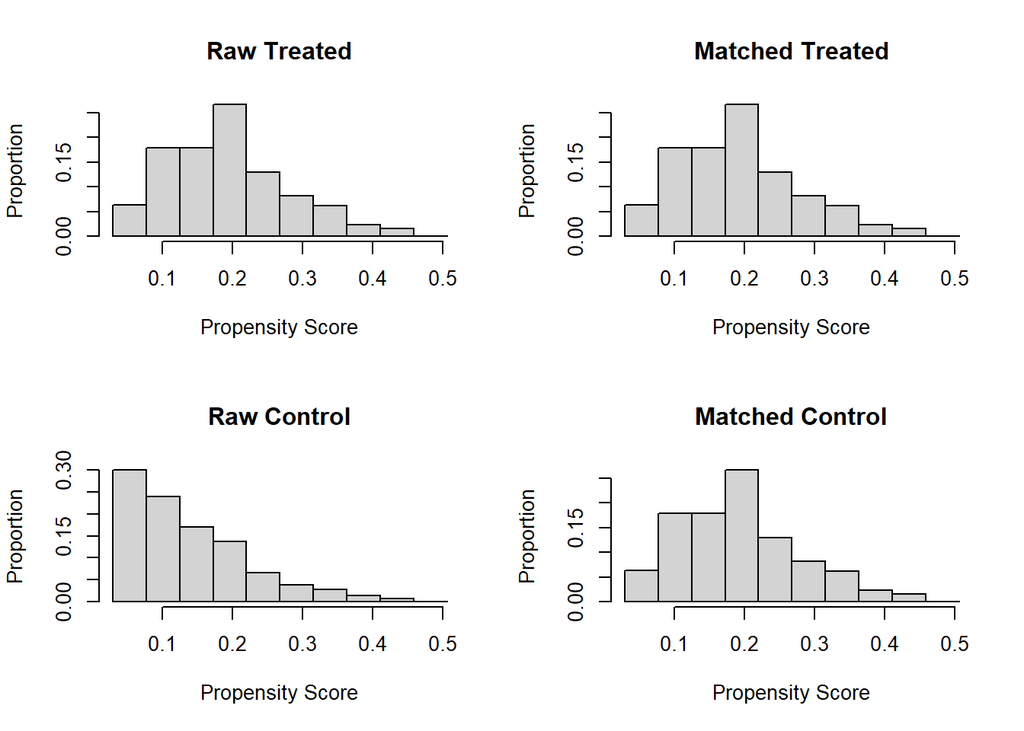

```r
# simple plot - check out the cobalt package for fancier options, or use ggplot2 to create your own!
plot(one_match, type = "hist")
```

Try extracting the data from *one_match* and creating a balance table like the one we did before, just this time using the new data. Scroll down for the answer when you’re ready.

```r
# grab data set
data_prop_match <- MatchIt::match.data(one_match)

# check balance
data_prop_match %>%
  dplyr::group_by(catholic) %>%
  dplyr::summarise_all(funs(mean)) %>%
  t() %>%
  as.data.frame() %>%
  add_rownames("variable") %>%
  dplyr::rename(no_catholic = V1, catholic = V2) %>%
  dplyr::mutate(difference = catholic - no_catholic,
         differencePerc = difference / (catholic + no_catholic)) %>%
  dplyr::mutate_if(is.numeric, round, 3) %>%
  knitr::kable() %>%
  kableExtra::kable_styling()
```

| variable | no_catholic | catholic | difference | differencePerc |
| --- | --- | --- | --- | --- |
| catholic | 0.000 | 1.000 | 1.000 | 1.000 |
| c5r2mtsc_std | 0.314 | 0.210 | -0.104 | -0.199 |
| race_white | 0.725 | 0.741 | 0.016 | 0.011 |
| p5hmage | 39.434 | 39.593 | 0.159 | 0.002 |
| w3income | 77144.785 | 82568.936 | 5424.151 | 0.034 |
| p5numpla | 1.089 | 1.092 | 0.003 | 0.001 |
| w3momed_hsb | 0.248 | 0.223 | -0.025 | -0.052 |
| distance | 0.184 | 0.193 | 0.009 | 0.023 |
| weights | 1.000 | 1.000 | 0.000 | 0.000 |

Those means look very close. Hooray.

Finally, estimate the treatment effect on the matched data set:

```r
summary(lm(c5r2mtsc_std ~ catholic,
           data = data_prop_match))
```

```
##
## Call:
## lm(formula = c5r2mtsc_std ~ catholic, data = data_prop_match)
##
## Residuals:
##     Min      1Q  Median      3Q     Max
## -3.4654 -0.5658  0.0564  0.6064  3.1198
##
## Coefficients:
##             Estimate Std. Error t value Pr(>|t|)
## (Intercept)  0.31381    0.02862  10.966  < 2e-16 ***
## catholic    -0.10415    0.03784  -2.752  0.00596 **
## ---
## Signif. codes:  0 '***' 0.001 '**' 0.01 '*' 0.05 '.' 0.1 ' ' 1
##
## Residual standard error: 0.9103 on 2362 degrees of freedom
## Multiple R-squared:  0.003197,   Adjusted R-squared:  0.002775
## F-statistic: 7.575 on 1 and 2362 DF,  p-value: 0.005963
```

As with the exact matching, we can see that those that did not attend Catholic school performed better on the test than those who did, and the results are statistically significant.

We can see the direction and magnitude of the covariate effects using a simple linear model:

```r
lm_matched <- lm(c5r2mtsc_std ~ catholic + race_white + p5hmage +
                  I(w3income / 1000) + p5numpla + w3momed_hsb,
                 data = data_prop_match)

# use the stargazer package to view the output
# NOTE: you MUST include results = "asis" in the chunk header for this to be visible once knitted
stargazer(lm_matched, type = "html", align = TRUE)
```

|  | *Dependent variable:* |
| --- | --- |
|  | c5r2mtsc_std |
| catholic | -0.135*** |
|  | (0.036) |
| race_white | 0.365*** |
|  | (0.041) |
| p5hmage | 0.013*** |
|  | (0.003) |
| I(w3income/1000) | 0.003*** |
|  | (0.0004) |
| p5numpla | -0.028 |
|  | (0.058) |
| w3momed_hsb | -0.295*** |
|  | (0.043) |
| Constant | -0.573*** |
|  | (0.157) |
| Observations | 2,364 |
| R<sup>2</sup> | 0.111 |
| Adjusted R<sup>2</sup> | 0.109 |
| Residual Std. Error | 0.860 (df = 2357) |
| F Statistic | 49.212*** (df = 6; 2357) |
| *Note:* | p<0.1; p<0.05; p<0.01 |